# practical machine learning assignment 4

### QUESTION 1

#### Consider a 3rd order polynomial:

f(x) = a0 + a1x + a2x2 + a3x3 Suppose we are given a set of samples of this function (xi, yi)) for 1 <= i <= N.The least squares residual is given by R = (yi - f(xi)) Using calculus, determine the values for a0, a1, a2, and a3 that minimize this residual. Hint1: consider where the residual R is at a minimum. Hint 2: Try to write in matrix form in terms of a linear system of equations. Write a0, a1, a2, and a3 in those terms.

```python
import numpy as np
from scipy import optimize
import numpy as np
import matplotlib.pyplot as plt
from sklearn.preprocessing import PolynomialFeatures
from sklearn.linear_model import LinearRegression
from sklearn.pipeline import make_pipeline
from sklearn.model_selection import train_test_split,GridSearchCV, KFold, cross_val_score
from sklearn.neighbors import KNeighborsClassifier
from sklearn.metrics import mean_squared_error
from sklearn.preprocessing import StandardScaler
```

```python
#Lets create a samples of 3rd order polynomial
xi = np.linspace(0,1,20)
xi
```

```
array([0.        , 0.05263158, 0.10526316, 0.15789474, 0.21052632,
       0.26315789, 0.31578947, 0.36842105, 0.42105263, 0.47368421,
       0.52631579, 0.57894737, 0.63157895, 0.68421053, 0.73684211,
       0.78947368, 0.84210526, 0.89473684, 0.94736842, 1.        ])
```

```python
yi = 1 + xi + xi**2 + xi**3
A = np.vstack([np.ones(len(xi)),xi,xi**2,xi**3]).T
print(A)
```

```
[[1.00000000e+00 0.00000000e+00 0.00000000e+00 0.00000000e+00]
 [1.00000000e+00 5.26315789e-02 2.77008310e-03 1.45793847e-04]
 [1.00000000e+00 1.05263158e-01 1.10803324e-02 1.16635078e-03]
 [1.00000000e+00 1.57894737e-01 2.49307479e-02 3.93643388e-03]
 [1.00000000e+00 2.10526316e-01 4.43213296e-02 9.33080624e-03]
 [1.00000000e+00 2.63157895e-01 6.92520776e-02 1.82242309e-02]
 [1.00000000e+00 3.15789474e-01 9.97229917e-02 3.14914711e-02]
 [1.00000000e+00 3.68421053e-01 1.35734072e-01 5.00072897e-02]
 [1.00000000e+00 4.21052632e-01 1.77285319e-01 7.46464499e-02]
 [1.00000000e+00 4.73684211e-01 2.24376731e-01 1.06283715e-01]
 [1.00000000e+00 5.26315789e-01 2.77008310e-01 1.45793847e-01]
 [1.00000000e+00 5.78947368e-01 3.35180055e-01 1.94051611e-01]
 [1.00000000e+00 6.31578947e-01 3.98891967e-01 2.51931768e-01]
 [1.00000000e+00 6.84210526e-01 4.68144044e-01 3.20309083e-01]
 [1.00000000e+00 7.36842105e-01 5.42936288e-01 4.00058318e-01]
 [1.00000000e+00 7.89473684e-01 6.23268698e-01 4.92054235e-01]
 [1.00000000e+00 8.42105263e-01 7.09141274e-01 5.97171599e-01]
 [1.00000000e+00 8.94736842e-01 8.00554017e-01 7.16285173e-01]
 [1.00000000e+00 9.47368421e-01 8.97506925e-01 8.50269719e-01]
 [1.00000000e+00 1.00000000e+00 1.00000000e+00 1.00000000e+00]]
```

```python
yi = yi[:,np.newaxis]
coeffs_a = np.dot((np.dot(np.linalg.inv(np.dot(A.T,A)),A.T)),yi)
print(coeffs_a)
```

```
[[1.]
 [1.]
 [1.]
 [1.]]
```

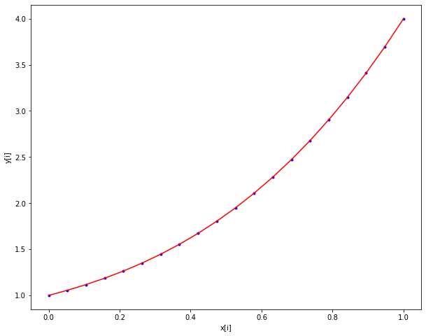

```python
plt.figure(num=1,figsize = (10,8))
plt.plot(xi, yi, 'b.')
plt.plot(xi, 1 + coeffs_a[0]*xi + coeffs_a[1]*xi**2 + coeffs_a[2]*xi**3, 'r')
plt.xlabel('x[i]')
plt.ylabel('y[i]')
plt.show()
```

### QUESTION 2

#### Consider the function f(x) = xsin(x). Write code to take samples of this function (at least 50). Add normally-distributed random noise to the function (e.g. use np.random.normal).

#### Reconstruct the function using the given samples using polynomial models as we did in class. Try this reconstruction over at least 5 different polynomial orders (suggest linear up to 5th order). Which order of polynomial gives the best reconstruction and why? Use the model assessment methodology we have discussed in class.

```python
def my_func(x):
    return (x * np.sin(x)) + np.random.normal(loc=0,scale=1,size=len(x))
x2 = np.arange(0,100,2)
y2 = my_func(x2)

print(y2)
```

```
[  1.75339077   0.70413575  -3.38395318   0.88999769   6.52851751
  -5.62831641  -5.77801923  14.71524158  -4.84867777 -14.94662095
  18.78162109  -0.27788313 -24.19442265  21.68949501   6.41936814
 -30.14471148  16.38519354  19.54978221 -36.59824372  11.25188585
  29.17060673 -38.77309076  -0.77746167  41.35919651 -37.23356004
 -13.37841013  51.70433096 -31.91327482 -29.15760081  58.16832986
 -17.80255514 -46.23331689  58.38410692  -2.04673394 -61.22752349
  52.65100445  16.10326042 -71.94776739  42.68483781  39.45725051
 -81.12398811  25.06169305  60.11747028 -79.77979727   5.2188472
  79.37241059 -71.6335501  -23.27081154  95.18298661 -56.35580731]
```

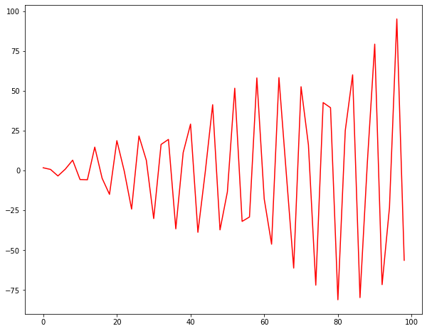

```python
plt.figure(num=2,figsize=(10,8))
plt.plot(x2,y2,"r")
plt.show()
print()
```

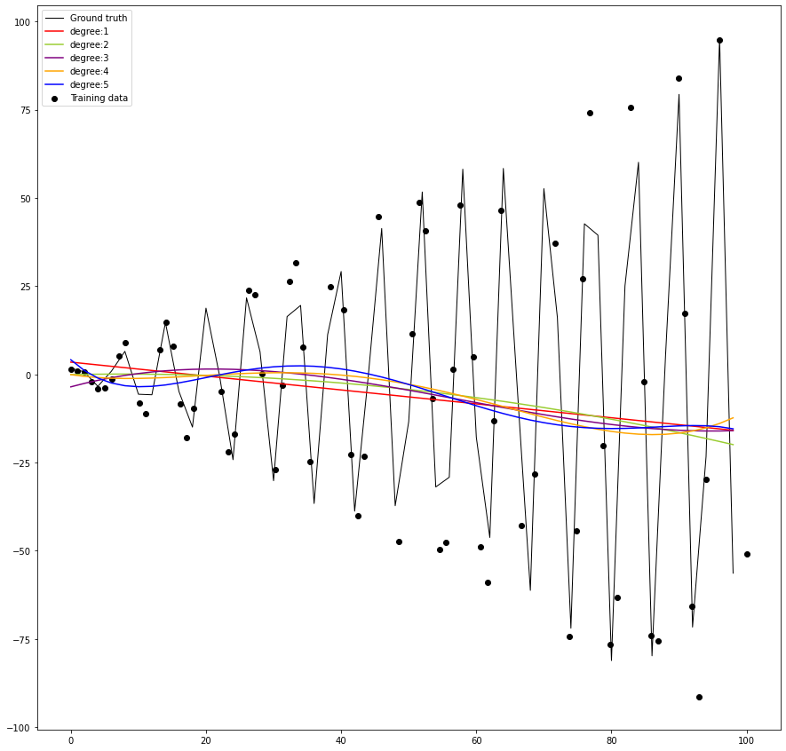

```python
rng = np.random.RandomState(0)
x_train = np.linspace(0, 100 ,100)
x_train = np.sort(rng.choice(x_train, size=70, replace=False))
y_train = my_func(x_train)

# create 2D-array versions of these arrays to feed to transformers
x2 = x2[:, np.newaxis]
x_train = x_train[:,np.newaxis]


lw = 1
fig, ax = plt.subplots(figsize=(15, 15))
ax.set_prop_cycle(color=["black", "red","yellowgreen", "purple", "orange", "blue"])
ax.plot(x2,y2,linewidth=lw, label="Ground truth")
ax.scatter(x_train,y_train,label="Training data")

# polynomial fit
for degree in [1,2,3,4,5]:
    model = make_pipeline(PolynomialFeatures(degree), LinearRegression())
    model.fit(x_train,y_train)
    y_pred = model.predict(x2)
    ax.plot(x2,y_pred, label=f'degree:{degree}')
plt.legend()
plt.show()
```

#### Getting the best degree

```
Best degree 1 with RMSE 53.28017282940002
```

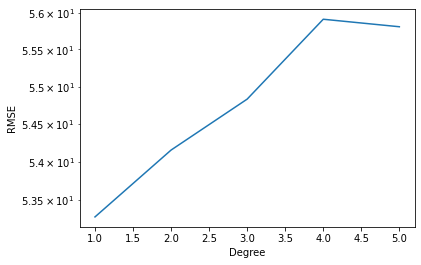

```python
x2 = np.arange(0,100,2).reshape(-1,1)
y2 = ((x2 * np.sin(x2)) + np.random.normal(loc=0,scale=1,size=(len(x2))))


x_train, x_test, y_train, y_test = train_test_split(x2, y2, test_size=0.3)

rmses = []
degrees = np.arange(1, 6)
min_rmse, min_deg = 1e10, 0

for deg in degrees:

    # Train features
    poly_features = PolynomialFeatures(degree=deg, include_bias=False)
    x_poly_train = poly_features.fit_transform(x_train)

    # Linear regression
    poly_reg = LinearRegression()
    poly_reg.fit(x_poly_train, y_train)

    # Compare with test data
    x_poly_test = poly_features.fit_transform(x_test)
    poly_predict = poly_reg.predict(x_poly_test)
    poly_mse = mean_squared_error(y_test, poly_predict)
    poly_rmse = np.sqrt(poly_mse)
    rmses.append(poly_rmse)

    # Cross-validation of degree
    if min_rmse > poly_rmse:
        min_rmse = poly_rmse
        min_deg = deg

# Plot and present results
print('Best degree {} with RMSE {}'.format(min_deg, min_rmse))

fig = plt.figure()
ax = fig.add_subplot(111)
ax.plot(degrees, rmses)
ax.set_yscale('log')
ax.set_xlabel('Degree')
ax.set_ylabel('RMSE')
```